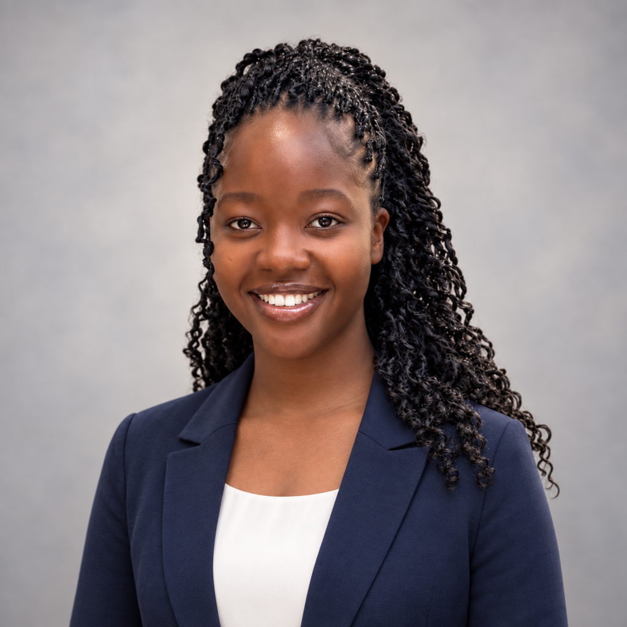

# Elgiva Abbey

## Bio

Hi, I’m Elgiva! I’m a Ghana-trained physician and full-time MPH student at the Johns Hopkins Bloomberg School of Public Health, after practicing clinical medicine in Ghana for over three years.

Medicine taught me to ask two questions: What does this patient need today, and what needs to change so more people receive better care tomorrow? That question led me into public health, and now shapes my interest in building sustainable models of care for children with serious illnesses in resource-limited settings.

## Data, Statistics & This Course

My experience so far leans much more toward clinical and public health reasoning than programming. I’m still in the early chapters here. By the end of this course, I hope to feel confident cleaning real-world datasets, writing reproducible code, and turning numbers into insights that actually improve care. Being less intimidated by error messages would be a nice bonus too.

## Five Fun Facts About Me

1. I have a deep sense of wanderlust. I love discovering new places and cultures.
2. Off the clock, I’m probably under a blanket binge-reading romantic comedies or sci-fi.
3. I love stage plays. If I weren’t a physician, I might be chasing a career as the next Viola Davis.
4. I’ve called both Ghana and Baltimore home, and each has shaped how I see the world.
5. One of my favorite thought-provoking images is Apollo 8’s Earthrise — more on that below.

## Something I Find Inspiring: Apollo 8’s Earthrise

NASA’s [Earthrise photograph](https://science.nasa.gov/resource/image-earthrise/), taken during the Apollo 8 mission in 1968, shows Earth rising over the Moon’s horizon. It is small, beautiful, and fragile.

I first saw it in an environmental health lecture on entropy and irreversible planetary damage. It captures something I try to carry into public health: our health is inseparable from our environment, and prevention matters most before harm becomes irreversible.